# Diversity of *Scaptotrigona Mexicana* and *Melipona beecheii*

Haydé Peruyero (haydeeperuyero@gmail.com)

2025-01-22

First, we need to read the biom files. In this file, we found the following **Kingdoms**.

```
##
##   Archaea  Bacteria Eukaryota   Viruses
##  3.595197 74.456261  1.228130 20.720412
```

Obtain the quantity of reads in each sample.

## Deep reads

In the following plot, we can see the deep of the reads for each sample in the honey of *Scaptotrigona mexicana* and *Melipona beecheii* specie.

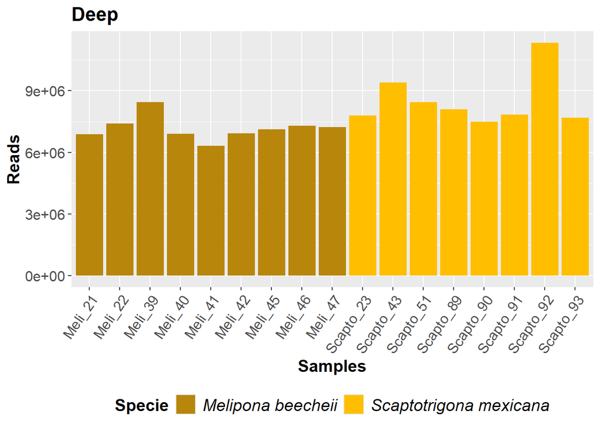

We will work with the `Bacteria` subset.

# Kigdoms

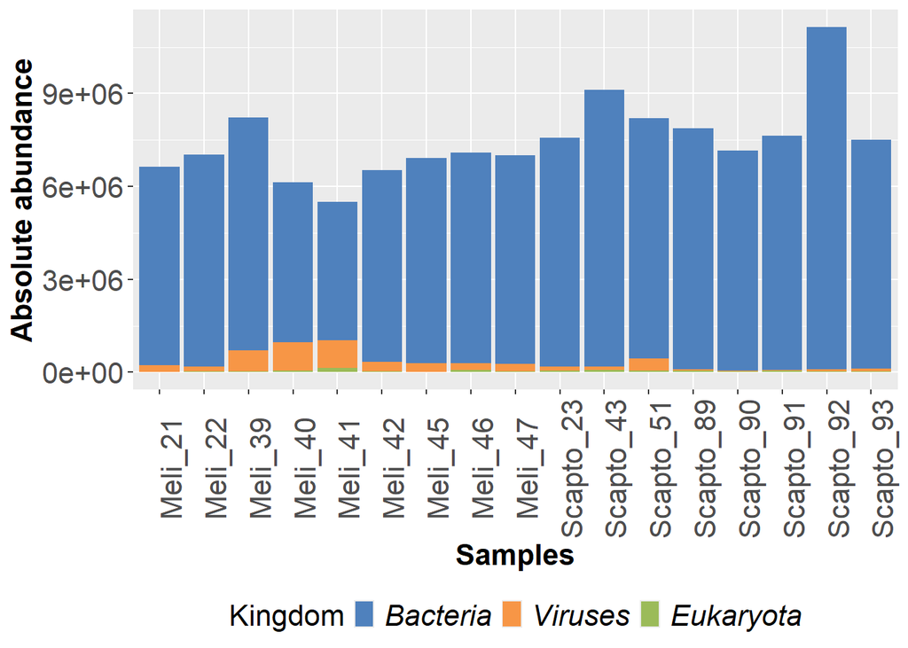

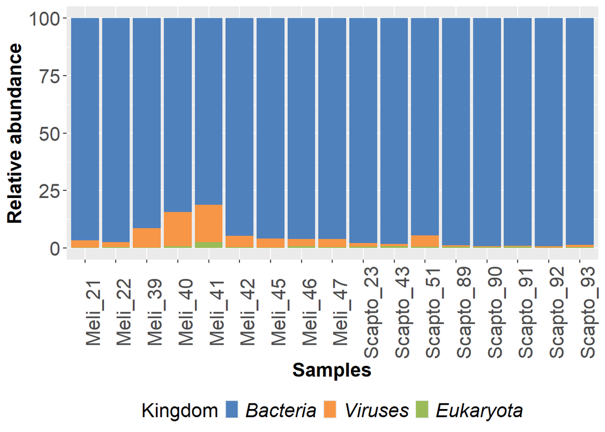

# Bacteria

## Alpha diversity

- **Observed:** The Observed index simply counts the number of unique species (or Operational Taxonomic Units, OTUs) in a sample. It is a basic measure of species richness.

**Formula:**
$$S_{\text{obs}} = \sum_{i=1}^S I(n_i >
0)$$
where $S$ is the total number of species and $I(n_i > 0)$ is an indicator function that is 1 if species $i$ is observed (i.e., $n_i > 0$) and 0 otherwise.

- **Chao1:** The Chao1 index is an estimator of the true species richness in a sample, accounting for the number of rare species. It is particularly useful when dealing with undersampled communities.

**Formula:**
$$\text{Chao1} = S_{\text{obs}} +
\frac{F_1(F_1 - 1)}{2(F_2 + 1)}$$
where $F_1$ is the number of singletons (species observed exactly once) and $F_2$ is the number of doubletons (species observed exactly twice).

- **Shannon:** The Shannon index, also known as Shannon-Wiener or Shannon-Weaver index, measures the diversity in a community by considering both the richness and the evenness of species. It accounts for the abundance of each species.

**Formula:**
$$H' = -\sum_{i=1}^S p_i \ln(p_i)$$
where $S$ is the total number of species and $p_i$ is the proportion of individuals belonging to species $i$.

In the case of the samples of honey, we can observed the following with respect to the diversity of these indexes.

In general, we can see the following:

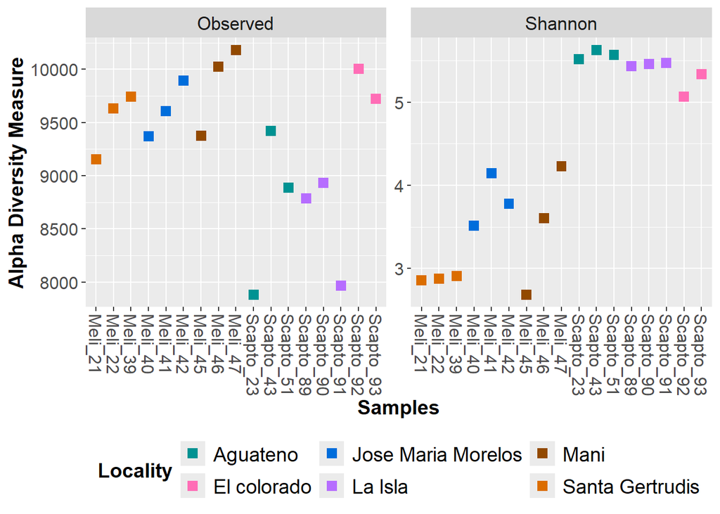

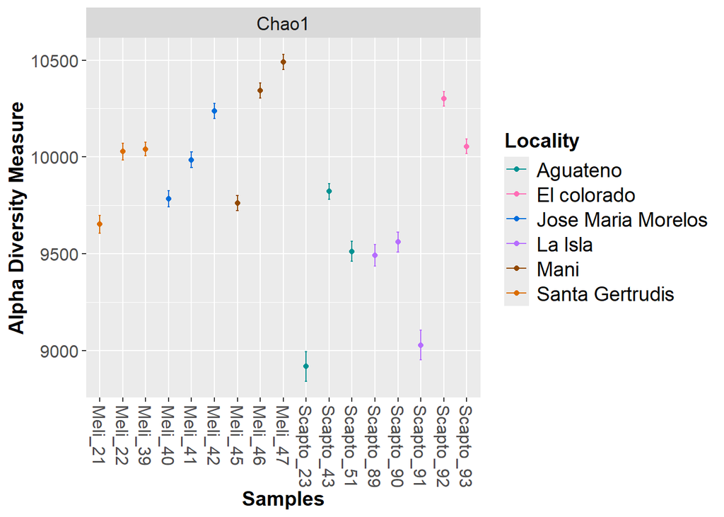

## Beta diversity

Beta diversity measures the differences in species composition between samples. The following plot is an NMDS (Non-metric Multidimensional Scaling) plot, which is commonly used to visualize beta diversity.

### Interpretation of the NMDS Plot

1. **Axes Interpretation**:
   - **NMDS1** and **NMDS2** represent the two dimensions that best capture the differences in species composition among the samples.
   - The scales on these axes are arbitrary and do not have direct biological meaning. Instead, the relative positions of the points are what matter.
2. **Points Representation**:
   - Each point on the plot represents a sample.
   - The closer two points are to each other, the more similar their species compositions are.
   - Conversely, points that are farther apart indicate samples with more dissimilar species compositions.
3. **Clustering**:
   - If points form clusters, it indicates groups of samples that have similar species compositions.
   - In this plot, there seems to be some clustering, which suggests that certain samples have more similar communities.
4. **Stress Value (not shown)**:
   - Normally, NMDS plots include a stress value, which indicates how well the two-dimensional plot represents the multi-dimensional data. Lower stress values (typically <0.2) suggest a good representation.
   - Since the stress value is not shown here, it’s important to be cautious in interpreting the distances, but generally, NMDS plots provide a useful visual summary.

### Overall Interpretation

- The NMDS plot shows the beta diversity among the samples, highlighting similarities and differences in their species compositions.
- Samples that are close to each other on the plot have similar species compositions, while those that are far apart are more dissimilar.
- Identifying clusters or gradients in the plot can help infer patterns related to environmental gradients, treatments, or other factors influencing the community composition.

In the plot we can see that there are some correlation between the samples and the city of the samples.

```
## Square root transformation
## Wisconsin double standardization
## *** Best solution repeated 2 times
```

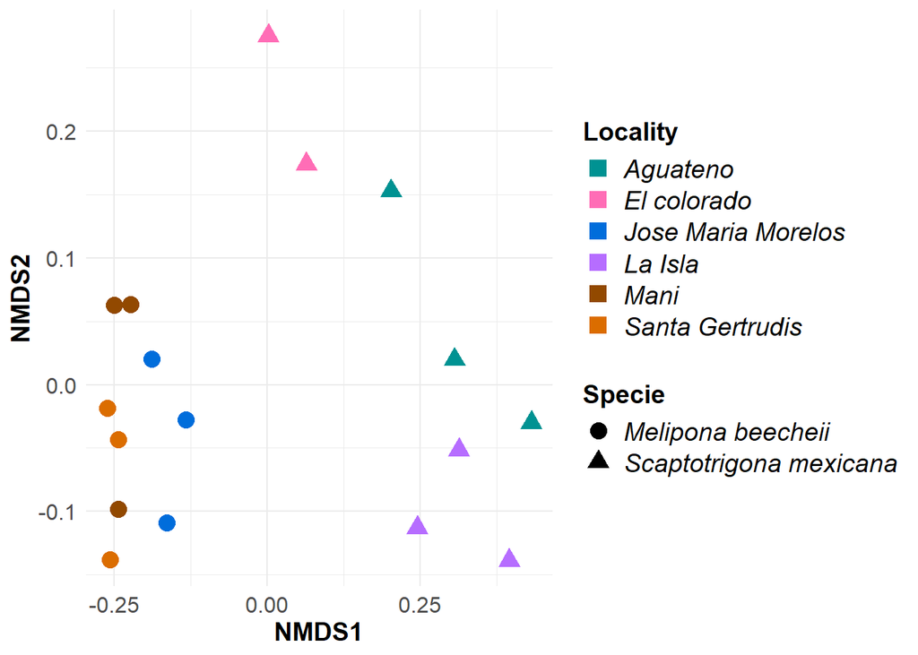

## Relative abundance

The relative abundance of taxa in metagenomic samples provides insights into the proportional representation of microbial groups within a given community. Relative abundance is calculated as the proportion of a specific taxon’s abundance to the total abundance across all taxa in a sample. This metric is commonly expressed as a percentage or fraction.

For this study, we computed the relative abundance of bacterial taxa at the phylum and genus levels to identify dominant and rare microbial groups in the samples. High relative abundance values indicate predominant taxa that likely play significant roles in the community’s ecological functions, while low relative abundance values suggest the presence of less dominant or transient taxa.

Visualization of relative abundance data was performed using bar plots, allowing for an intuitive comparison of microbial composition between samples and experimental conditions. These comparisons provide critical information about the dynamics of microbial populations and their potential functional implications.

### Predominant Phyla in Honey Samples

The analysis of microbial composition revealed that the phyla *Bacillota* and *Pseudomonadota* were predominant in the honey samples from both *M. beecheii* and *S. mexicana*. These phyla accounted for the majority of the microbial community across all samples, suggesting their critical role in shaping the microbiota of these honeys.

The dominance of Bacillota may be associated with its known members, including lactic acid bacteria, which contribute to the antimicrobial properties and preservation of honey. Similarly, Pseudomonadota includes taxa that could influence the physicochemical properties of honey through their metabolic activities. The consistent presence of these phyla in both honey types highlights their potential importance in the functional and ecological roles of stingless bee honeys.

Further analysis at the genus level is required to better understand the specific taxa contributing to these patterns and their potential functional implications.

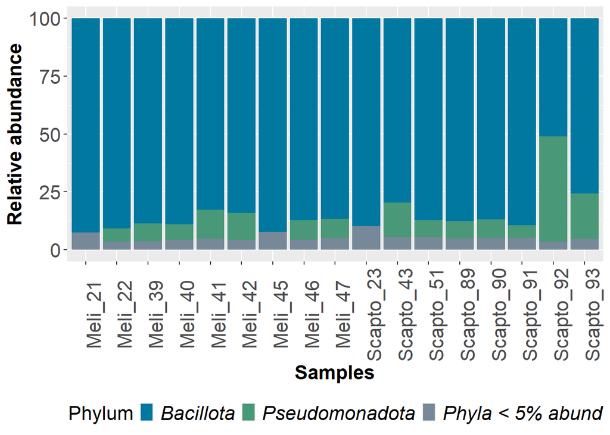

### Predominant Genera in Honey Samples

The microbial composition at the genus level showed clear distinctions between the honey samples of *M. beecheii* and *S. mexicana*. The predominant genera identified were *Acetilactobacillus*, *Apilactobacillus*, *Lactobacillus*, *Nicoliella*, *Pantoea*, *Tatumella*, and *Fructobacillus*.

*Acetilactobacillus* was the most abundant genus in the honey samples from *M. beecheii*, while *Apilactobacillus* dominated in the samples from *S. mexicana*. Interestingly, the genera *Tatumella* and *Pantoea* were only detected in two samples from *S. mexicana*, suggesting a more specific or transient presence in these honeys.

These results suggest distinct microbial signatures for each bee species, which may reflect differences in their foraging behaviors, hive environments, or nectar sources. The predominance of lactic acid bacteria such as *Acetilactobacillus*, *Apilactobacillus*, and *Lactobacillus* supports their potential role in the fermentation processes and preservation of honey.

Further investigation into the functional roles of these genera may provide insights into their contributions to the unique physicochemical properties of these stingless bee honeys.

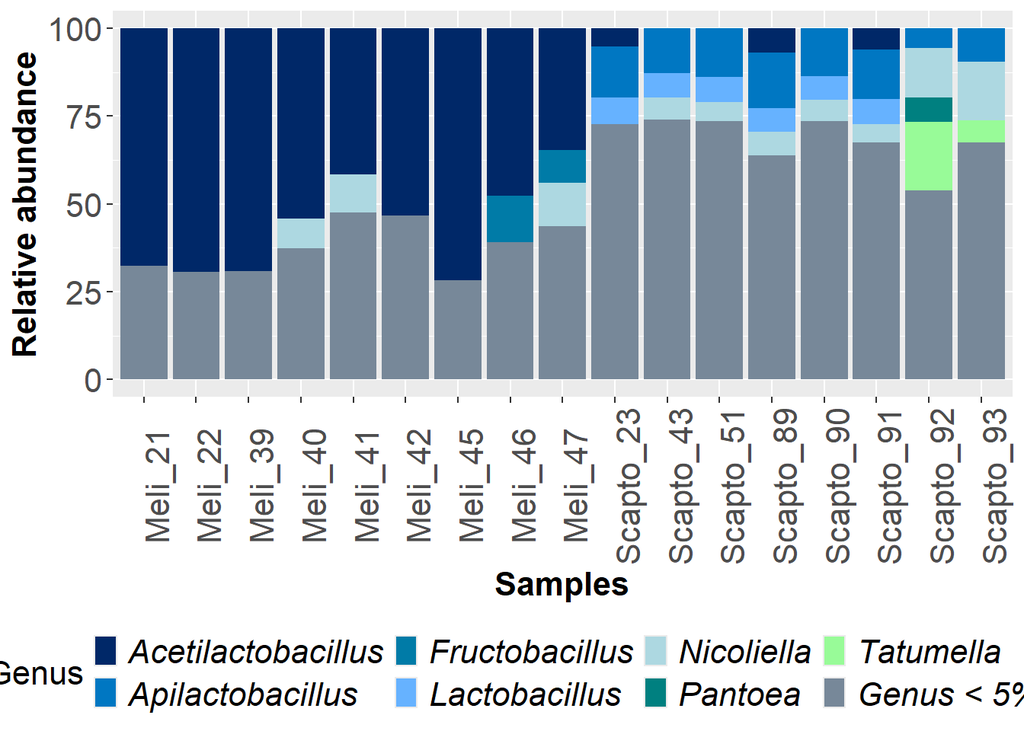

# Virus

## Alfa diversity

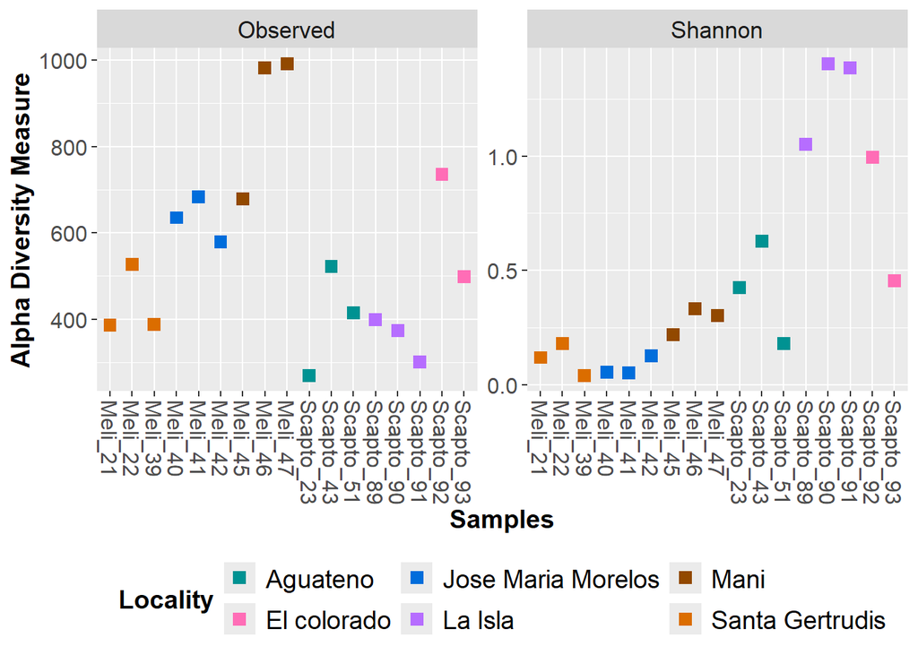

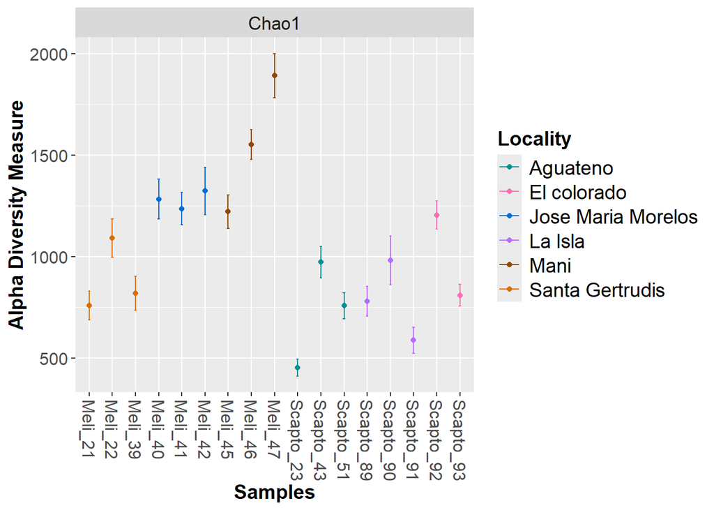

## Beta diversity

```
## Square root transformation
## Wisconsin double standardization
## *** Best solution repeated 14 times
```

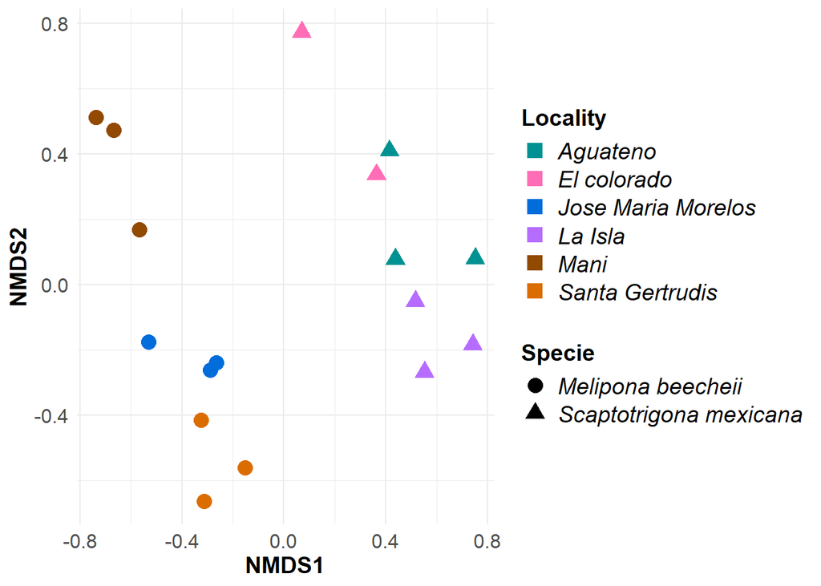

## Relative abundance

### Predominant Phyla in Honey Samples in Phylum

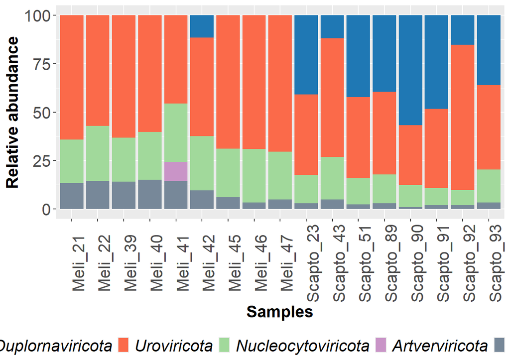

### Predominant Genera in Honey Samples

```
##  [1] "Genus < 5% abund"  "Fijivirus"         "Vellamovirus"
##  [4] "Muscavirus"        "Chloriridovirus"   "Andhravirus"
##  [7] "Petruschkyvirus"   "Goslarvirus"       "Litunavirus"
## [10] "Bequatrovirus"     "Valbvirus"         "Mimivirus"
## [13] "Douglaswolinvirus" "Fadolivirus"       "Leucotheavirus"
## [16] "Solendovirus"      "Ascovirus"         "Kehishuvirus"
## [19] "Wphvirus"          "Elpedvirus"        "Tupanvirus"
## [22] "Klosneuvirus"
```

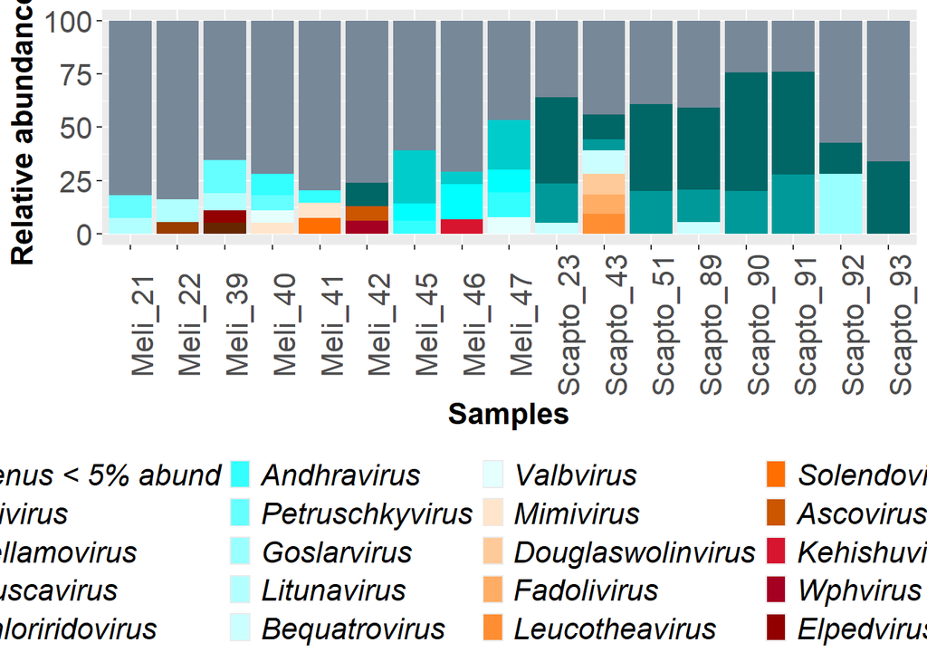

## Eukaryota

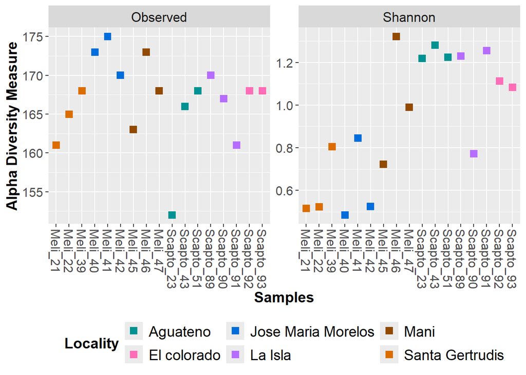

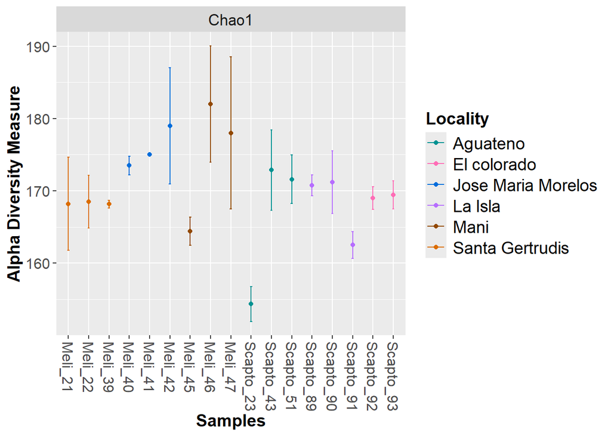

## Beta diversity

```
## Square root transformation
## Wisconsin double standardization
## *** Best solution repeated 7 times
```

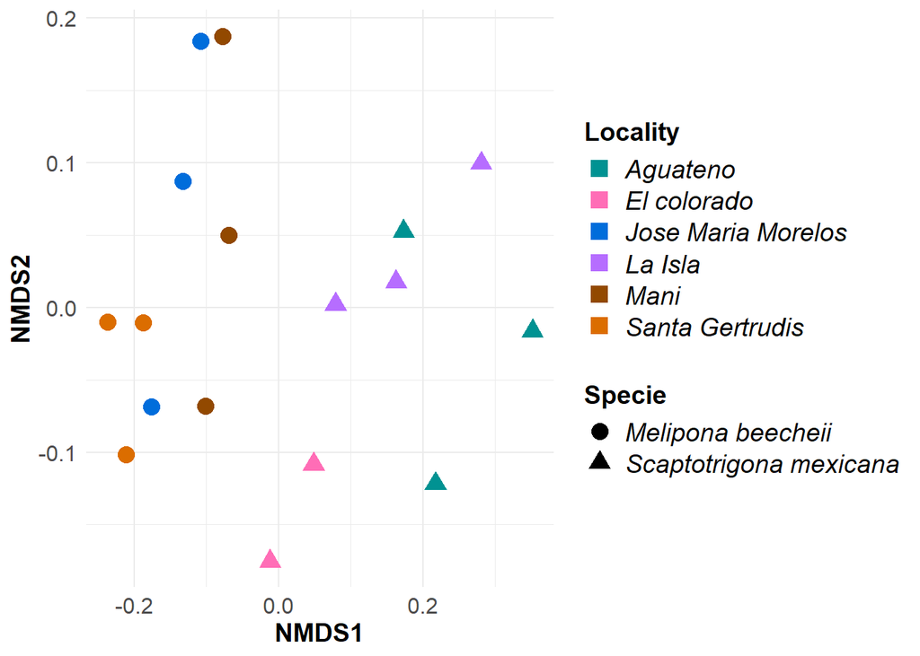

Existen 14 Phylums diferentes y dentro de esos solo 3 son Fungi. Se va a filtrar por solo esos.

```
##  [1] Chordata        Ascomycota      Apicomplexa     Basidiomycota
##  [5] Parabasalia     Evosea          Bacillariophyta Euglenozoa
##  [9] Fornicata       Cercozoa        Ciliophora      Microsporidia
## [13] Streptophyta    Heterolobosea
## 14 Levels: Apicomplexa Ascomycota Bacillariophyta Basidiomycota ... Streptophyta
```

```r
rel_phylum_global <- tax_glom(data, taxrank = 'Phylum')
rel_phylum_global <- transform_sample_counts(rel_phylum_global, function(x) x*100 / sum(x) )
rel_phyl_global_df<-psmelt(rel_phylum_global) # convert to data frame
#str(rel_phyl_global_df)
#rel_phyl_global_df$Phylum[rel_phyl_global_df$Abundance < 5] <- "Phyla < 5% abund"
rel_phyl_global_df$Phylum <- as.factor(rel_phyl_global_df$Phylum)
```

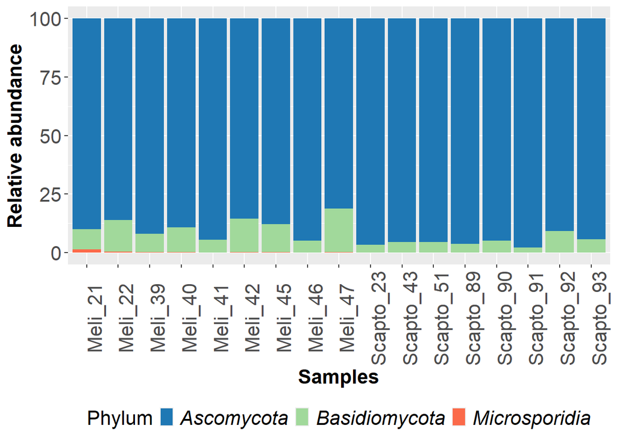

### Predominant Genera in Honey Samples

```
##  [1] "Genus < 5% abund"    "Aspergillus"         "Fusarium"
##  [4] "Tetrapisispora"      "Pyricularia"         "Saccharomyces"
##  [7] "Kluyveromyces"       "Schizosaccharomyces" "Candida"
## [10] "Thermothielavioides" "Fulvia"              "Kazachstania"
## [13] "Cryptococcus"        "Penicillium"         "Colletotrichum"
## [16] "Trichoderma"         "Puccinia"            "Komagataella"
```

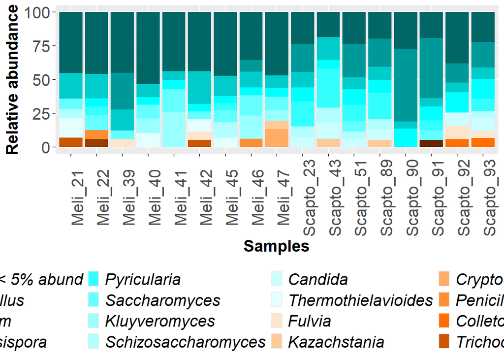

# Statistics

Porcentaje de los Phylums: “Ascomycota”, “Basidiomycota”, “Microsporidia”.

```
## [1] 0.4218748
```

Porcentaje del Género *Acetilactobacillus* en *Melipona beecheii*.

```r
#data Bacteria
#54.21

# Filtrar por un género específico
genero_of_interest <- "Acetilactobacillus"
subset_genero <- subset_taxa(data, Genus == genero_of_interest)

# Filtrar por el metadato `specie`
specie_of_interest <- "Melipona beecheii"
subset_specie <- subset_samples(data, Specie == specie_of_interest)

# Calcular el total de reads para esa especie
total_reads_specie <- sum(otu_table(subset_specie))

# Calcular el total de reads del género específico dentro de esa especie
subset_genero_specie <- subset_taxa(subset_specie, Genus == genero_of_interest)
genero_reads_specie <- sum(otu_table(subset_genero_specie))

# Calcular el porcentaje
porcentaje_genero <- (genero_reads_specie / total_reads_specie) * 100
porcentaje_genero
```

```
## [1] 54.21725
```

Porcentaje del género *Apilactobacillus* en *Scaptotrigona mexicana*.

```r
#dataB
#10.56
# Filtrar por un género específico
genero_of_interest <- "Apilactobacillus"
subset_genero <- subset_taxa(data, Genus == genero_of_interest)

# Filtrar por el metadato `specie`
specie_of_interest <- "Scaptotrigona mexicana"
subset_specie <- subset_samples(data, Specie == specie_of_interest)

# Calcular el total de reads para esa especie
total_reads_specie <- sum(otu_table(subset_specie))

# Calcular el total de reads del género específico dentro de esa especie
subset_genero_specie <- subset_taxa(subset_specie, Genus == genero_of_interest)
genero_reads_specie <- sum(otu_table(subset_genero_specie))

# Calcular el porcentaje
porcentaje_genero <- (genero_reads_specie / total_reads_specie) * 100
porcentaje_genero
```

```
## [1] 10.56657
```